# HDT3_DecisionTree

Alejandro Alvarez, Jorge De Leon, Roberto Castillo

2022-03-04

```r
library("tidyverse")
library("dplyr")
library("ggplot2")
library("httr")
library("readr")
library(rpart)
library(caret)
library(randomForest)
library(tree)
library(rpart.plot)
library(car)
library(cluster) #Para calcular la silueta
library(e1071)#para cmeans
library(mclust) #mixtures of gaussians
library(fpc) #para hacer el plotcluster
library(NbClust) #Para determinar el número de clusters óptimo
library(factoextra) #Para hacer gráficos bonitos de clustering
library(hopkins) #Para revisar si vale la pena hacer agrupamiento
library(GGally) #Para hacer el conjunto de graficos
library(FeatureImpCluster) #Para revisar la importancia de las variables en los grupos.
library(pheatmap) #Para hacer mapa de calor
```

Importación del set de datos a partir del .csv

```r
house <- read.csv("./train.csv", stringsAsFactors = F)
```

##—CLASIFICACION DE VARIABLES—## Id -> Variable continu MSSubClass -> Variable continua MSZoning -> Variable categórica  
LotFrontage -> Variable continua  
LotArea -> Variable discreta Street -> Variable categórica  
Alley -> Variable categórica  
LotShape -> Variable categórica  
LandContour -> Variable categórica  
Utilities -> Variable categórica  
LotConfig -> Variable categórica  
LandSlope -> Variable categórica  
Neighborhood -> Variable categórica  
Condition1 -> Variable categórica  
Condition2 -> Variable categórica  
BldgType -> Variable categórica  
HouseStyle -> Variable categórica  
OverallQual -> Variable continua  
OverallCond -> Variable continua  
YearBuilt -> Variable discreta  
YearRemodAdd -> Variable discreta  
RoofStyle -> Variable categórica  
RoofMatl -> Variable categórica  
Exterior1st -> Variable categórica Exterior2nd -> Variable categórica  
MasVnrType -> Variable categórica  
MasVnrArea -> Variable discreta  
ExterQual -> Variable categórica  
ExterCond -> Variable categórica  
Foundation -> Variable categórica  
BsmtQual -> Variable categórica  
BsmtCond -> Variable categórica  
BsmtExposure -> Variable categórica  
BsmtFinType1 -> Variable categórica  
BsmtFinSF1 -> Variable discreta  
BsmtFinType2 -> Variable categórica  
BsmtFinSF2 -> Variable discreta  
BsmtUnfSF -> Variable discreta  
TotalBsmtSF -> Variable discreta  
Heating -> Variable categórica  
HeatingQC -> Variable categórica  
CentralAir -> Variable categórica  
Electrical -> Variable categórica  
1stFlrSF -> Variable continua 2ndFlrSF -> Variable continua LowQualFinSF -> Variable continua GrLivArea -> Variable discreta BsmtFullBath -> Variable continua BsmtHalfBath-> Variable continua FullBath -> Variable continua HalfBath -> Variable continua  
Bedroom -> Variable continua Kitchen -> Variable continua KitchenQual -> Variable categórica  
TotRmsAbvGrd -> Variable discreta  
Functional -> Variable categórica  
Fireplaces -> Variable discreta  
FireplaceQu -> Variable categórica  
GarageType -> Variable categórica  
GarageYrBlt -> Variable discreta GarageFinish -> Variable categórica  
GarageCars -> Variable continua GarageArea -> Variable continua GarageQual -> Variable categórica  
GarageCond -> Variable categórica  
PavedDrive -> Variable categórica  
WoodDeckSF -> Variable continua OpenPorchSF -> Variable continua EnclosedPorch -> Variable continua 3SsnPorch -> Variable continua ScreenPorch -> Variable continua PoolArea -> Variable continua PoolQC -> Variable categórica  
Fence -> Variable categórica  
MiscFeature -> Variable categórica  
MiscVal -> Variable continua MoSold -> Variable discreta YrSold -> Variable discreta SaleType -> Variable categórica  
SaleCondition -> Variable categórica  
SalePrice -> Variable discreta  
##—-Exploración del Set de datos—-##

Resumen del set de datos

```r
summary(house)
```

```
##        Id           MSSubClass      MSZoning          LotFrontage
##  Min.   :   1.0   Min.   : 20.0   Length:1460        Min.   : 21.00
##  1st Qu.: 365.8   1st Qu.: 20.0   Class :character   1st Qu.: 59.00
##  Median : 730.5   Median : 50.0   Mode  :character   Median : 69.00
##  Mean   : 730.5   Mean   : 56.9                      Mean   : 70.05
##  3rd Qu.:1095.2   3rd Qu.: 70.0                      3rd Qu.: 80.00
##  Max.   :1460.0   Max.   :190.0                      Max.   :313.00
##                                                      NA's   :259
##     LotArea          Street             Alley             LotShape
##  Min.   :  1300   Length:1460        Length:1460        Length:1460
##  1st Qu.:  7554   Class :character   Class :character   Class :character
##  Median :  9478   Mode  :character   Mode  :character   Mode  :character
##  Mean   : 10517
##  3rd Qu.: 11602
##  Max.   :215245
##
##  LandContour         Utilities          LotConfig          LandSlope
##  Length:1460        Length:1460        Length:1460        Length:1460
##  Class :character   Class :character   Class :character   Class :character
##  Mode  :character   Mode  :character   Mode  :character   Mode  :character
##
##
##
##
##  Neighborhood        Condition1         Condition2          BldgType
##  Length:1460        Length:1460        Length:1460        Length:1460
##  Class :character   Class :character   Class :character   Class :character
##  Mode  :character   Mode  :character   Mode  :character   Mode  :character
##
##
##
##
##   HouseStyle         OverallQual      OverallCond      YearBuilt
##  Length:1460        Min.   : 1.000   Min.   :1.000   Min.   :1872
##  Class :character   1st Qu.: 5.000   1st Qu.:5.000   1st Qu.:1954
##  Mode  :character   Median : 6.000   Median :5.000   Median :1973
##                     Mean   : 6.099   Mean   :5.575   Mean   :1971
##                     3rd Qu.: 7.000   3rd Qu.:6.000   3rd Qu.:2000
##                     Max.   :10.000   Max.   :9.000   Max.   :2010
##
```

[output cut: 113 more lines]

```
##  Min.   : 1.000   Min.   :2006   Length:1460        Length:1460
##  1st Qu.: 5.000   1st Qu.:2007   Class :character   Class :character
##  Median : 6.000   Median :2008   Mode  :character   Mode  :character
##  Mean   : 6.322   Mean   :2008
##  3rd Qu.: 8.000   3rd Qu.:2009
##  Max.   :12.000   Max.   :2010
##
##    SalePrice
##  Min.   : 34900
##  1st Qu.:129975
##  Median :163000
##  Mean   :180921
##  3rd Qu.:214000
##  Max.   :755000
##
```

Se crea un conteo de columnas y observaciones (filas) del conjunto de datos

```r
#ncol count -> col variable
col <- ncol(house)
#Print
```

```r
cat("El número de columnas para el conjunto de datos es de :", col, "\n")
```

```
## El número de columnas para el conjunto de datos es de : 81
```

```r
#nrow count -> row variable
row <- nrow(house)
#Print
cat("El número de observaciones para el conjunto de datos es de :", row)
```

```
## El número de observaciones para el conjunto de datos es de : 1460
```

Top 30 de casas vendidas con precios más altos (siendo la más alta de $755,000)

```r
top10 <- arrange(house, desc(house$SalePrice))
head (select(top10, "Neighborhood", "SalePrice"),30)
```

```
##    Neighborhood SalePrice
## 1       NoRidge    755000
## 2       NoRidge    745000
## 3       NoRidge    625000
## 4       NridgHt    611657
## 5       NridgHt    582933
## 6       StoneBr    556581
## 7       NridgHt    555000
## 8       StoneBr    538000
## 9       StoneBr    501837
## 10      NridgHt    485000
## 11      OldTown    475000
## 12      NoRidge    466500
## 13      NridgHt    465000
## 14      NridgHt    451950
```

[output cut: 16 more lines]

Ventas por Areas/vecindarios ordenados de mayor a menor, siendo la de más incidencia North Ames

```r
byneighborhood <- house %>% group_by(house$Neighborhood) %>% summarise(freq=n()) %>% ungroup()
byneighborhood <- arrange(byneighborhood, desc(byneighborhood$freq))
print(as_tibble(byneighborhood), n = 25)
```

```
## # A tibble: 25 x 2
##    `house$Neighborhood`  freq
##    <chr>                <int>
##  1 NAmes                  225
##  2 CollgCr                150
##  3 OldTown                113
##  4 Edwards                100
##  5 Somerst                 86
##  6 Gilbert                 79
##  7 NridgHt                 77
##  8 Sawyer                  74
##  9 NWAmes                  73
## 10 SawyerW                 59
## 11 BrkSide                 58
## 12 Crawfor                 51
## 13 Mitchel                 49
## 14 NoRidge                 41
## 15 Timber                  38
## 16 IDOTRR                  37
## 17 ClearCr                 28
## 18 StoneBr                 25
## 19 SWISU                   25
## 20 Blmngtn                 17
## 21 MeadowV                 17
## 22 BrDale                  16
## 23 Veenker                 11
## 24 NPkVill                  9
## 25 Blueste                  2
```

Ventas por año ordenados de mayor a menor, siendo el año con mayor ventas 2009

```r
yearly <- house %>% group_by(house$YrSold) %>% summarise(freq=n()) %>% ungroup()
yearly <- arrange(yearly, desc(yearly$freq))
print(as_tibble(yearly), n = 10)
```

```
## # A tibble: 5 x 2
##   `house$YrSold`  freq
##            <int> <int>
## 1           2009   338
## 2           2007   329
## 3           2006   314
## 4           2008   304
## 5           2010   175
```

Ventas según la condición de la vivienda. Habiendo una diferencia significativa con una tendencia de inclinación a las de condición intermedia (5).

```r
conditions <- house %>% group_by(house$OverallCond) %>% summarise(freq=n()) %>% ungroup()
conditions <- arrange(conditions, desc(conditions$freq))
print(as_tibble(conditions), n = 10)
```

```
## # A tibble: 9 x 2
##   `house$OverallCond`  freq
##                 <int> <int>
## 1                   5   821
## 2                   6   252
## 3                   7   205
## 4                   8    72
## 5                   4    57
## 6                   3    25
## 7                   9    22
## 8                   2     5
## 9                   1     1
```

Gráfico de ventas por año y ventas anuales segun condición de la vivienda. Se puede observar que hay una consistencia en el número de ventas anuales de viviendas, con un descenso en el año 2010. Adicionalmente, pudimos confirmar que en efecto las casas de condición intermedia (5) fueron las más vendidas a través de los años.

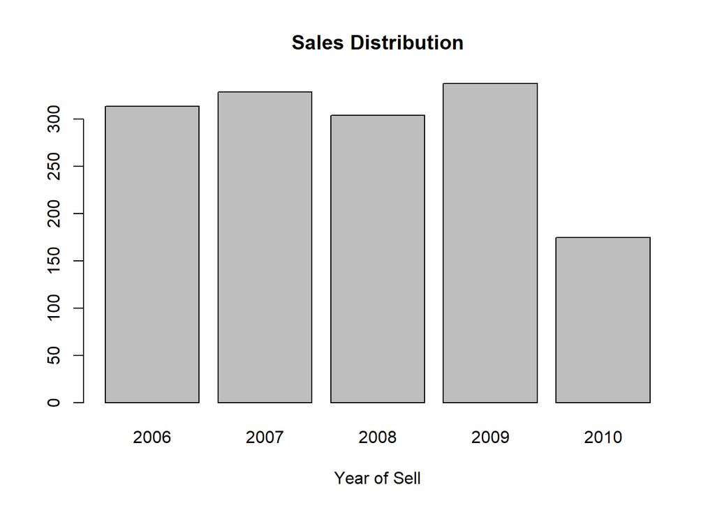

```r
counts0 <- table(house$YrSold)
barplot(counts0, main="Sales Distribution",
   xlab="Year of Sell")
```

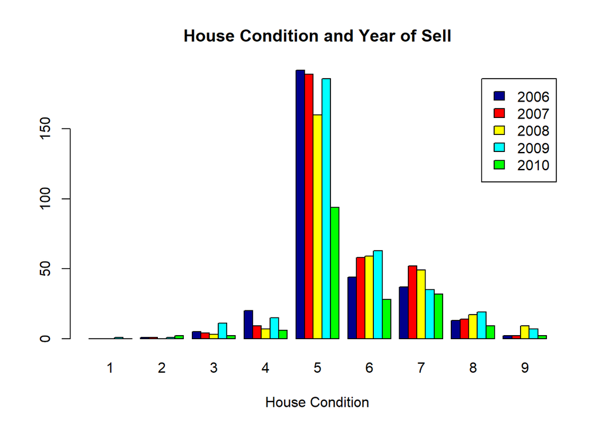

```r
counts <- table(house$YrSold, house$OverallCond)
barplot(counts, main="House Condition and Year of Sell",
  xlab="House Condition", col=c("darkblue","red", "yellow", "cyan", "green"),
  legend = rownames(counts), beside=TRUE)
```

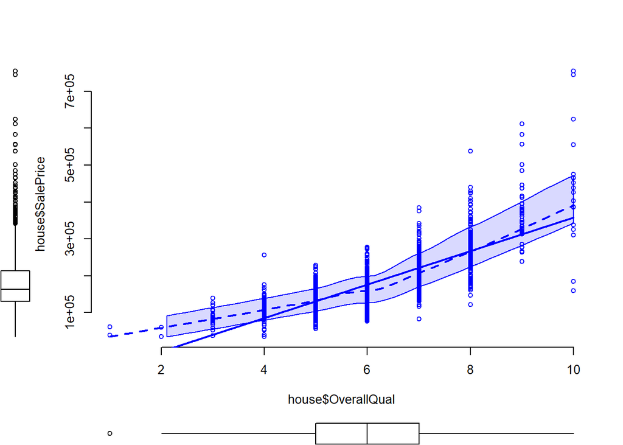

```r
scatterplot(house$SalePrice ~  house$OverallQual, data = house, smoother = FALSE, grid = FALSE, frame = FALSE)
```

Planteamiento de pregunta: La condición tiene alguna correlación con el precio de venta? Observando el gráfico de dispersion podemos observar que no existe tal relación y que la decisión es influida por otros factores

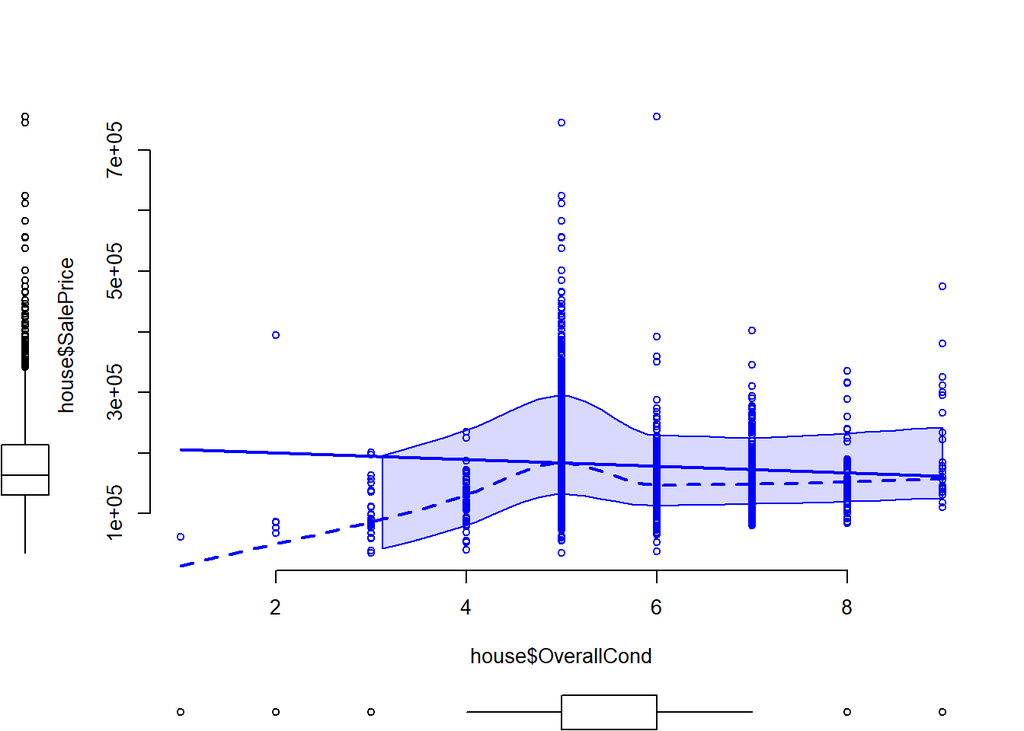

```r
scatterplot(house$SalePrice ~  house$OverallCond, data = house, smoother = FALSE, grid = FALSE, frame = FALSE)
```

División de los cuartiles en precios de venta de las casas

```r
quant <- quantile(house$SalePric)
quant
```

```
##     0%    25%    50%    75%   100%
##  34900 129975 163000 214000 755000
```

##—CLUSTERING DE VARIABLES—## Variables seleccionadas para agrupación: *OverallQual*  
OverallCond  
*GrLivArea*  
BedroomAbvGr *TotRmsAbvGrd*  
GarageCars  
*SalePrice* YearBuilt *LotArea

Se calcula el valor del estadístico de Hopkins.

```r
clusterhouse <- fread("./train.csv", select = c("OverallQual","OverallCond" ,"GrLivArea", "BedroomAbvGr", "TotRmsAbvGrd", "GarageCars", "SalePrice", "YearBuilt", "LotArea", "LotFrontage"))
clusterhouse$LotFrontage[is.na(clusterhouse$LotFrontage)]<-0.0
set.seed(123)
clusterhouse<-clusterhouse[complete.cases("./train.csv")]
clusterhouse<-scale(clusterhouse)
hopkins(clusterhouse)
```

```
## [1] 0.9999428
```

Dado que estadistico de Hopkings esta bastante alejado de 0.5 se puede inferir que los datos no son aleatorios hay altas posibilidades de que sea factible el agrupamiento de las variables seleccionadas.

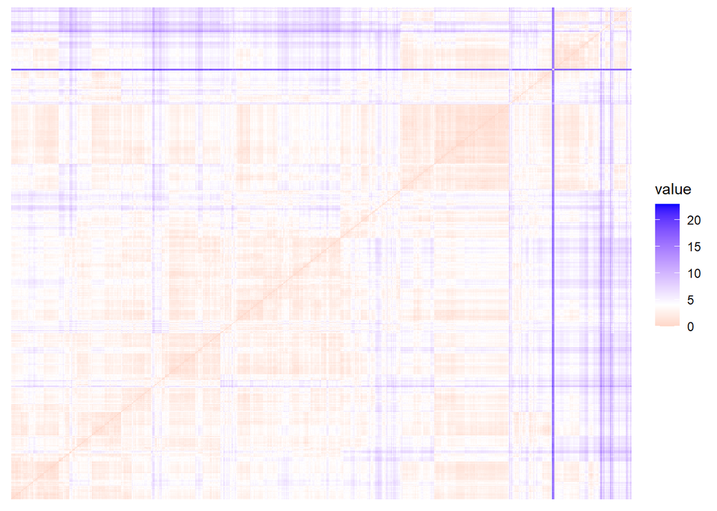

```r
clusterhouse_dist <- dist(clusterhouse)
fviz_dist(clusterhouse_dist, show_labels = F)
```

Como se puede observar en la VAT sí se observan patrones por lo que es factible el agrupamiento, confirmando el valor obtenido con el estadístico de Hopkings.

Se procede a realizar la prueba de codo para poder determinar un número de agrupaciones factibles.

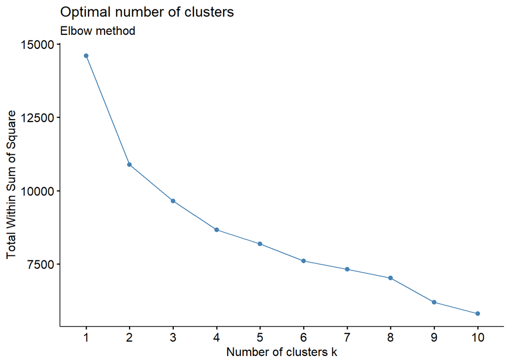

```r
fviz_nbclust(clusterhouse, kmeans, method = "wss") +
labs(subtitle = "Elbow method")
```

Se procede a realizar la prueba de silueta para poder comparar con el método de codo realizado con anterioridad y poder determinar un número de agrupaciones factibles.

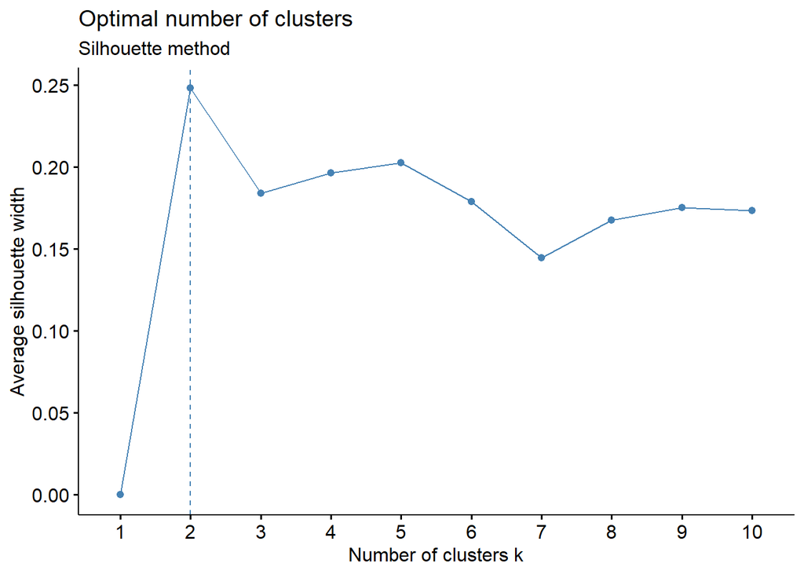

```r
fviz_nbclust(clusterhouse, kmeans, method = "silhouette") +
labs(subtitle = "Silhouette method")
```

```r
km<-kmeans(clusterhouse,2,iter.max =100)
clusterhouse$grupo<-km$cluster
```

```r
km
```

```
## K-means clustering with 2 clusters of sizes 649, 811
##
## Cluster means:
##   OverallQual OverallCond  GrLivArea BedroomAbvGr TotRmsAbvGrd GarageCars
## 1   0.7559839  -0.2940948  0.7161898    0.3129373    0.6331927  0.6600661
## 2  -0.6049736   0.2353484 -0.5731285   -0.2504270   -0.5067103 -0.5282157
##    SalePrice  YearBuilt    LotArea LotFrontage
## 1  0.7382572  0.6581675  0.2053650   0.2030253
## 2 -0.5907878 -0.5266963 -0.1643426  -0.1624703
##
## Clustering vector:
##    [1] 1 2 1 1 1 2 1 1 2 2 2 1 2 1 2 2 2 2 2 2 1 2 1 2 2 1 2 1 2 2 2 2 1 2 1 1 2
##   [38] 2 2 2 2 2 2 2 2 1 1 1 2 2 2 2 2 1 2 1 1 1 1 2 2 2 1 1 1 1 1 1 2 1 1 2 1 2
##   [75] 2 2 2 2 2 2 1 2 1 2 1 1 1 2 2 2 2 2 2 1 1 2 1 2 2 2 2 1 1 1 2 1 2 2 2 1 2
##  [112] 1 1 1 1 2 2 2 1 1 2 2 2 2 1 2 2 2 2 2 1 1 2 1 2 1 2 1 1 1 2 1 2 1 1 1 2 1
```

[output cut: 45 more lines]

```r
km$size
```

```
## [1] 649 811
```

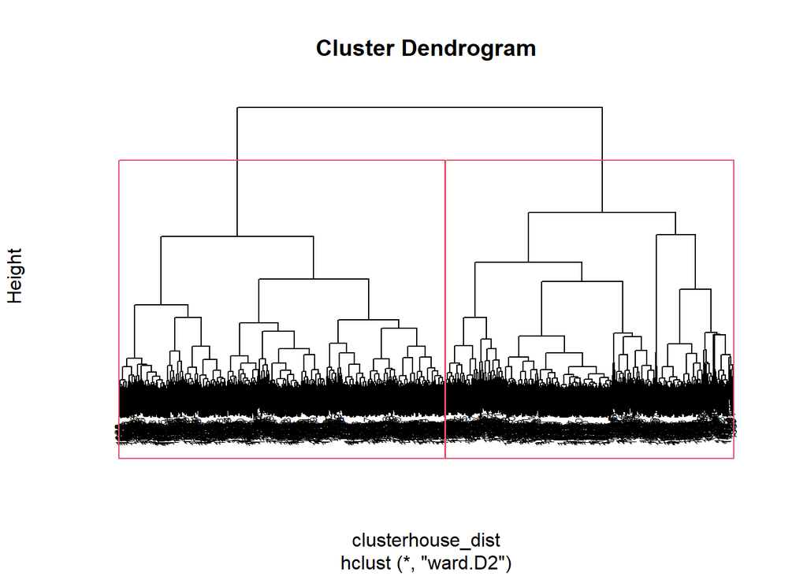

```r
hc<-hclust(clusterhouse_dist, method = "ward.D2")
plot(hc, cex=0.5, axes=FALSE) #Genera el dendograma
rect.hclust(hc,k=2)
```

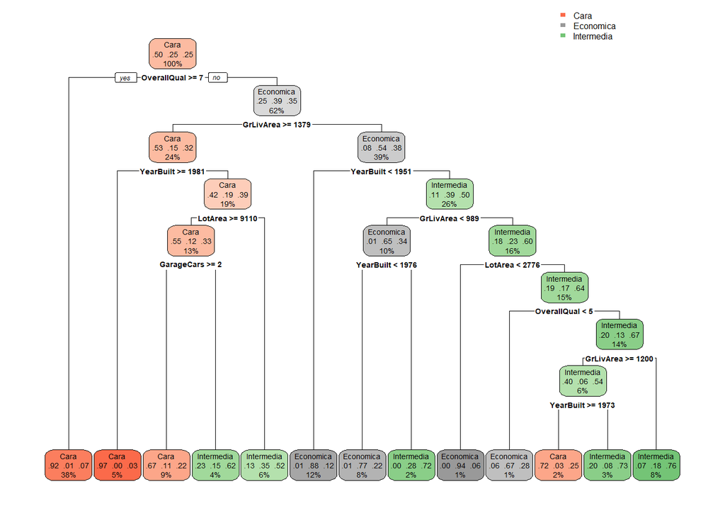

```r
set.seed(123)
#se toman las variables que se cree predicen propiamente el precio de la casa y el precio real de la casa.
#luego se reemplaza la columna del precio de la casa por una que lo clasifica como economica, intermedio o cara dependiendo de los percentiles.
data <- fread("./train.csv", select = c("OverallQual","OverallCond" ,"GrLivArea", "BedroomAbvGr", "TotRmsAbvGrd", "GarageCars", "SalePrice", "YearBuilt", "LotArea", "LotFrontage"))
data <- data %>% mutate(PriceRange = if_else(quant["0%"] <= SalePrice & SalePrice < quant["25%"], "Economica",
                                              if_else(quant["25%"] <= SalePrice & SalePrice < quant["50%"], "Intermedia", "Cara") ))
data$SalePrice <- NULL

data$LotFrontage[is.na(data$LotFrontage)]<-0.0

trainRowsNumber <- sample(1:nrow(data), 0.7*nrow(data))
train<-data[trainRowsNumber,]
test<-data[-trainRowsNumber,]
arbolModelo <- rpart(PriceRange~.,data,method = "class")
rpart.plot(arbolModelo)
```

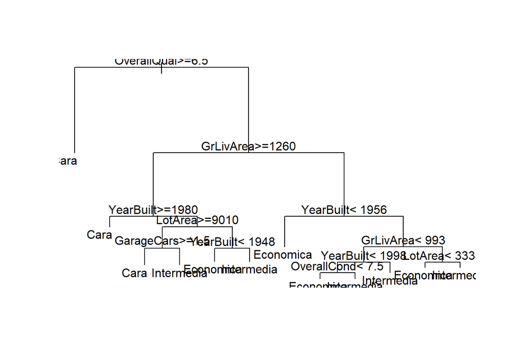

```r
save(train,test,arbolModelo, file = "Variables.RData")
load("Variables.RData")
dt_model<-rpart(PriceRange~., train,method = "class")
plot(dt_model);text(dt_model)
```

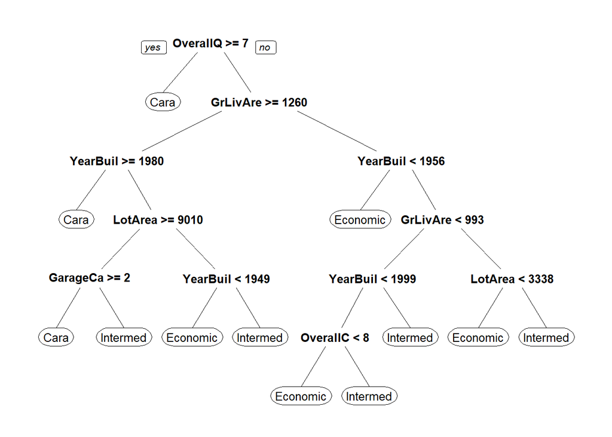

```r
prp(dt_model)
```

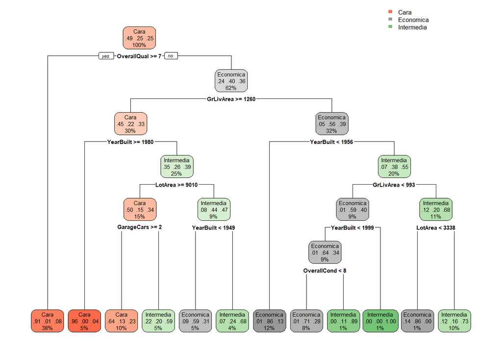

```r
rpart.plot(dt_model)
```

```r
head(test)
```

```
##    OverallQual OverallCond GrLivArea BedroomAbvGr TotRmsAbvGrd GarageCars
## 1:           7           5      1710            3            8          2
## 2:           7           5      1786            3            6          2
## 3:           8           5      1694            3            7          2
## 4:           7           5      1494            3            7          3
## 5:           6           5      1253            2            5          1
## 6:           8           5      2376            4            9          3
##    YearBuilt LotArea LotFrontage PriceRange
## 1:      2003    8450          65       Cara
## 2:      2001   11250          68       Cara
## 3:      2004   10084          75       Cara
## 4:      2006   10652          91       Cara
## 5:      1960   10920           0 Intermedia
## 6:      2005   14215         101       Cara
```

```r
prediccion <- predict(dt_model, newdata = test)
```

```r
#se obtiene la matriz de confusión para el árbol de clasificación
#como se puede observar, nada el modelo tiene una Accuracy del 80% esto es muy bueno, ya que es preciso sin mostrar tendencia al overfitting.
train$PriceRange=factor(train$PriceRange)
test$PriceRange=factor(test$PriceRange)

predicted_Price_Range<-apply(prediccion, 1, function(x) colnames(prediccion)[which.max(x)])
test$prediccion<-predicted_Price_Range

cfm<-confusionMatrix(as.factor(test$prediccion), test$PriceRange)
cfm
```

```
## Confusion Matrix and Statistics
##
##             Reference
## Prediction   Cara Economica Intermedia
##   Cara        215         4         25
##   Economica     2        85         26
##   Intermedia   10        20         52
##
## Overall Statistics
##
##                Accuracy : 0.8018
##                  95% CI : (0.7614, 0.8381)
##     No Information Rate : 0.5171
##     P-Value [Acc > NIR] : <2e-16
##
##                   Kappa : 0.6724
##
##  Mcnemar's Test P-Value : 0.0486
##
## Statistics by Class:
##
##                      Class: Cara Class: Economica Class: Intermedia
## Sensitivity               0.9471           0.7798            0.5049
## Specificity               0.8632           0.9152            0.9107
## Pos Pred Value            0.8811           0.7522            0.6341
## Neg Pred Value            0.9385           0.9264            0.8571
## Prevalence                0.5171           0.2483            0.2346
## Detection Rate            0.4897           0.1936            0.1185
## Detection Prevalence      0.5558           0.2574            0.1868
## Balanced Accuracy         0.9052           0.8475            0.7078
```

```r
ct<-trainControl(method = "cv",train, number=10, verboseIter=T)
modelorf<-train(PriceRange~., data=train, method="rpart", trControl = ct)
prediccionADVC<-predict(modelorf,newdata = test)
test$predADVC<-prediccionADVC


cfmCaret <- confusionMatrix(test$predADVC, test$PriceRange)
cfmCaret
```

```
## Confusion Matrix and Statistics
##
##             Reference
## Prediction   Cara Economica Intermedia
##   Cara        221        26         52
##   Economica     6        83         51
##   Intermedia    0         0          0
##
## Overall Statistics
##
##                Accuracy : 0.6925
##                  95% CI : (0.647, 0.7354)
##     No Information Rate : 0.5171
##     P-Value [Acc > NIR] : 6.154e-14
##
##                   Kappa : 0.4592
##
##  Mcnemar's Test P-Value : < 2.2e-16
##
## Statistics by Class:
##
##                      Class: Cara Class: Economica Class: Intermedia
## Sensitivity               0.9736           0.7615            0.0000
## Specificity               0.6321           0.8273            1.0000
## Pos Pred Value            0.7391           0.5929               NaN
## Neg Pred Value            0.9571           0.9130            0.7654
## Prevalence                0.5171           0.2483            0.2346
## Detection Rate            0.5034           0.1891            0.0000
## Detection Prevalence      0.6811           0.3189            0.0000
## Balanced Accuracy         0.8028           0.7944            0.5000
```

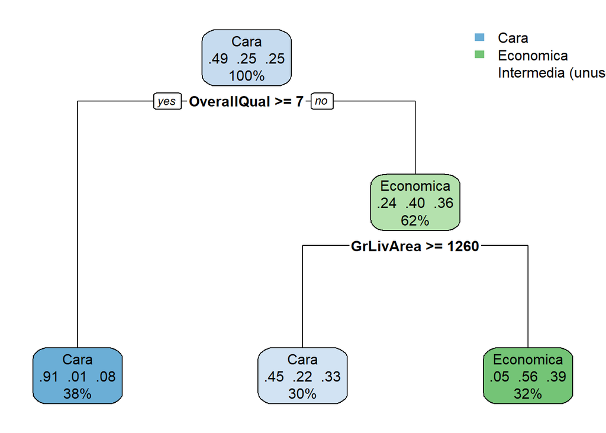

```r
rpart.plot(modelorf$finalModel)
```

```r
train$PriceRange=factor(train$PriceRange)
test$PriceRange=factor(test$PriceRange)
modelRandomF<-randomForest(PriceRange~.,data=train, na.action = na.exclude, method = "class")
PredictionRF<-predict(modelRandomF,newdata = test)
fulltest<-test
fulltest$predRF<-PredictionRF
cfmRandomForest <- confusionMatrix(fulltest$predRF, fulltest$PriceRange)
cfmRandomForest
```

```
## Confusion Matrix and Statistics
##
##             Reference
## Prediction   Cara Economica Intermedia
##   Cara        208         1         13
##   Economica     2        91         22
##   Intermedia   17        17         68
##
## Overall Statistics
##
##                Accuracy : 0.836
##                  95% CI : (0.798, 0.8694)
##     No Information Rate : 0.5171
##     P-Value [Acc > NIR] : <2e-16
##
##                   Kappa : 0.735
##
##  Mcnemar's Test P-Value : 0.6805
##
## Statistics by Class:
##
##                      Class: Cara Class: Economica Class: Intermedia
## Sensitivity               0.9163           0.8349            0.6602
## Specificity               0.9340           0.9273            0.8988
## Pos Pred Value            0.9369           0.7913            0.6667
## Neg Pred Value            0.9124           0.9444            0.8961
## Prevalence                0.5171           0.2483            0.2346
## Detection Rate            0.4738           0.2073            0.1549
## Detection Prevalence      0.5057           0.2620            0.2323
## Balanced Accuracy         0.9251           0.8811            0.7795
```

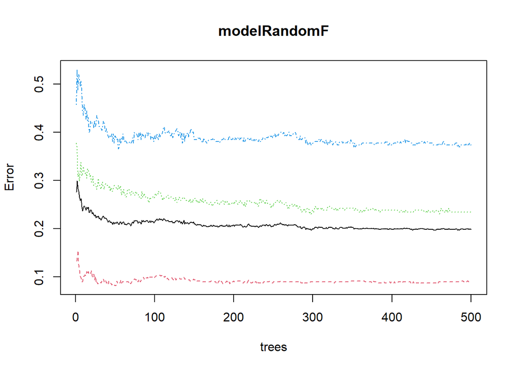

```r
plot(modelRandomF)
```